# Week 7 Assignment

Jessalyn Chuang

```r
# Load necessary packages.
library(here)
library(tidyverse)
#install.packages('dunn.test')
library(dunn.test)
library(gt)
#install.packages('paletteer')
library(paletteer)
#install.packages("tibble")
library(tibble)
```

#(1) Mann-Whitney U and Wilcoxon Signed-Rank Tests

1. Filter the dataset only for cutthroat trout. Create a figure that helps you to demonstrate why their snout-to-fork length (length_1_mm) by forest treatment (section) is not normally distributed. Clear-cut regions of the forest are denoted with CC, and old-growth regions of the forest are denoted as OG. Run a Mann-Whitney U test to see if ranks of fish lengths are significantly diﬀerent between forest treatment types. Write out your findings as you would in a report, including measures of central tendency and data spread for both forest treatments.

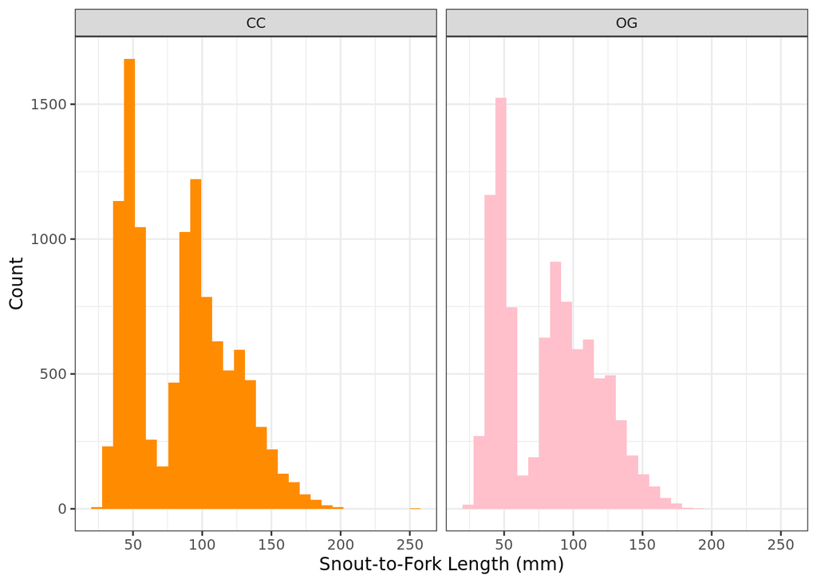

```r
#Null: There is no significant difference in ranks between CC and OG trout.
#Alt: There is a significant difference in ranks between CC and OG trout.

vertebrates_data <- read.csv(file = here("./Assignments/week7/and_vertebrates.csv"),
                           stringsAsFactors = TRUE)

trout_data <- filter(vertebrates_data,
                              species == "Cutthroat trout")

trout_fig1 <- ggplot(trout_data, aes(x = length_1_mm, fill = section)) +
  geom_histogram() +
  scale_fill_manual(values = c("darkorange", "pink", "purple")) +
  labs(x = "Snout-to-Fork Length (mm)", y = "Count") +
  facet_grid(.~section) +
  theme_bw() +
  theme(legend.position = "none")

trout_fig1
```

```r
cat("These distributions are not normally distributed because they exhibit multiple peaks (multimodality) and skewness. The left histogram (CC) has two prominent peaks, indicating possible subpopulations, while the right histogram (OG) shows a right-skewed distribution with an uneven spread. Normal distributions are unimodal and symmetric, which these are not.")
```

[output not shown]

```r
# Save data by section type.
trout_CC <- trout_data %>%
filter(section == "CC")
trout_OG <- trout_data %>%
filter(section == "OG")

mann_test <- wilcox.test(trout_CC$length_1_mm, trout_OG$length_1_mm,
paired = FALSE)

mann_test
```

```
##
##  Wilcoxon rank sum test with continuity correction
##
## data:  trout_CC$length_1_mm and trout_OG$length_1_mm
## W = 55178843, p-value = 7.697e-16
## alternative hypothesis: true location shift is not equal to 0
```

```r
trout_CC_median <- median(trout_CC$length_1_mm, na.rm = TRUE)
trout_CC_IQR <- IQR(trout_CC$length_1_mm, na.rm = TRUE)

trout_OG_median <- median(trout_OG$length_1_mm, na.rm = TRUE)
trout_OG_IQR <- IQR(trout_OG$length_1_mm, na.rm = TRUE)
```

Cutthroat trout species displayed significant diﬀerences in Snout-to-Fork length as determined by a Mann-Whitney U-Test (U = 55178843, p < 0.001). Therefore, we accept the alternative hypothesis that the ranks of the Snout-to-Fork length for Cutthroat trout in Clear-Cut regions (median = 88 mm, IQR = 61 mm) and Old-Growth regions (median = 84 mm, IQR = 60 mm) are significantly different.

2. Navigate to Canvas and download the trout_recapture.csv dataset; these data are originally part of the and_vertebrates.csv dataset, but they have been filtered to include only trout that were captured and tagged in 2014 and then re-captured in 2015. Create a figure that helps you demonstrate why their snout-to-fork length (length_1_mm) by year is not normally distributed. Run a Wilcoxon Signed-Rank test to see if ranks of fish lengths are significantly diﬀerent between years. Write out your findings as you would in a report, including measures of central tendency and data spread for both years.

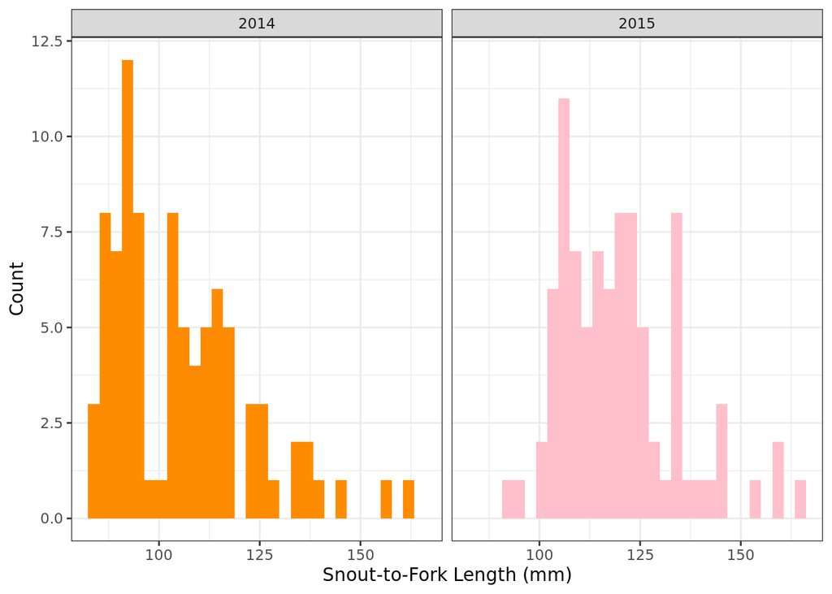

```r
#Null: The ranks of the fish lengths in 2014 and in 2015 are equal.
#Alternative: The ranks of the fish lengths in 2014 and in 2015 are not equal.
trout_recapture <- read.csv(file = here("./Assignments/week7/trout_recapture_v2.csv"),
                           stringsAsFactors = TRUE)

trout_fig2 <- ggplot(trout_recapture, aes(x = length_1_mm, fill = factor(year))) +
  geom_histogram() +
  scale_fill_manual(values = c("darkorange", "pink")) +
  labs(x = "Snout-to-Fork Length (mm)", y = "Count") +
  facet_grid(.~year) +
  theme_bw() +
  theme(legend.position = "none")

trout_fig2
```

```r
cat("These distributions are not normally distributed because they exhibit multimodality and skewness. The 2014 distribution has multiple peaks and gaps, indicating subpopulations, while the 2015 distribution is asymmetrical with a long tail. Normal distributions should be unimodal and symmetric, which these are not.")
```

[output not shown]

```r
# Save data by year.
trout_2014 <- trout_recapture %>%
filter(year == 2014)
trout_2015 <- trout_recapture %>%
filter(year == 2015)

wilcox_test <- wilcox.test(trout_2014$length_1_mm, trout_2015$length_1_mm,
paired = TRUE)

wilcox_test
```

```
##
##  Wilcoxon signed rank test with continuity correction
##
## data:  trout_2014$length_1_mm and trout_2015$length_1_mm
## V = 625.5, p-value = 4.973e-08
## alternative hypothesis: true location shift is not equal to 0
```

```r
trout_2014_median <- median(trout_2014$length_1_mm, na.rm = TRUE)
trout_2014_IQR <- IQR(trout_2014$length_1_mm, na.rm = TRUE)

trout_2015_median <- median(trout_2015$length_1_mm, na.rm = TRUE)
trout_2015_IQR <- IQR(trout_2015$length_1_mm, na.rm = TRUE)
```

Recaptured Cutthroat trout displayed significant diﬀerences in Snout-to-Fork length as determined by a Wilcoxon Signed-Rank Test (V = 625.5, p < 0.001). Therefore, we accept the alternative hypothesis that the ranks of the Snout-to-Fork length for Cutthroat trout in 2014 (median = 103.5 mm, IQR = 23.25 mm) and 2015 (median = 118 mm, IQR = 19 mm) are significantly different.

#(2) Kruskal Wallis and post-hoc Dunn’s Tests

1. Using the dataset you created above including only cutthroat trout, create a figure that helps you to demonstrate why their snout-to-fork length (length_1_mm) by reach (reach) is not normally distributed. Having verified this, run a Kruskal Wallis test to see if ranks of fish lengths are significantly diﬀerent among stream reaches. If you find there is a significant diﬀerence between at least two reaches, run a Dunn’s test. Write out your findings as you would in a report, including a measure of central tendency and data spread for all three reach sections.

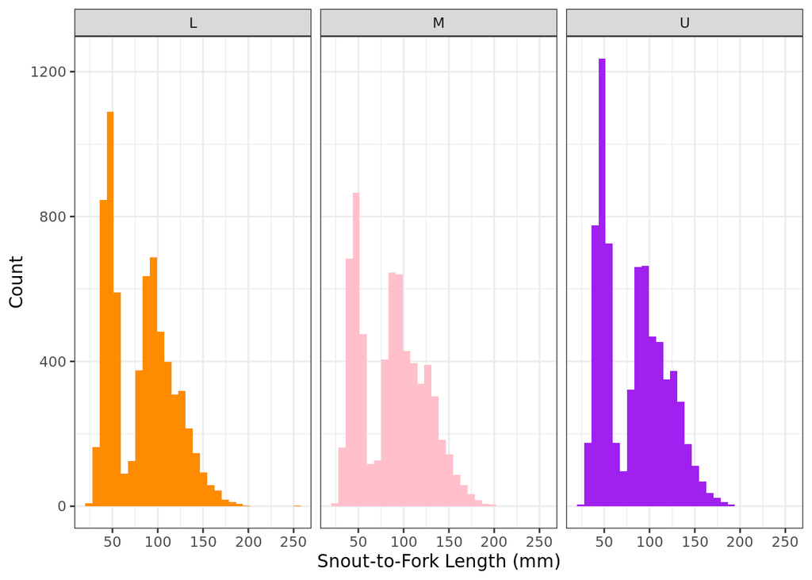

```r
#Null: The ranks of trout across L, M, and U stream reaches are equal.
#Alt: The ranks of trout across L, M, and U stream reaches are not equal.

trout_fig3 <- ggplot(trout_data, aes(x = length_1_mm, fill = reach)) +
  geom_histogram() +
  scale_fill_manual(values = c("darkorange", "pink", "purple")) +
  labs(x = "Snout-to-Fork Length (mm)", y = "Count") +
  facet_grid(.~reach) +
  theme_bw() +
  theme(legend.position = "none")

trout_fig3
```

```r
cat("These distributions are not normally distributed due to multimodality, skewness, and asymmetry. Each category (L, M, U) exhibits multiple peaks, suggesting the presence of subpopulations. Additionally, the distributions are right-skewed, with a longer tail extending towards higher Snout-to-Fork lengths. Normal distributions should be unimodal and symmetric, which these are not.")
```

[output not shown]

```r
kruskal_test <- kruskal.test(length_1_mm ~ reach, data = trout_data)

kruskal_test
```

```
##
##  Kruskal-Wallis rank sum test
##
## data:  length_1_mm by reach
## Kruskal-Wallis chi-squared = 77.394, df = 2, p-value < 2.2e-16
```

```r
# There is a significant difference between at least two reaches
dunn_test <- dunn.test(trout_data$length_1_mm, trout_data$reach)
```

```
##   Kruskal-Wallis rank sum test
##
## data: x and group
## Kruskal-Wallis chi-squared = 77.3942, df = 2, p-value = 0
##
##
##                            Comparison of x by group
##                                 (No adjustment)
## Col Mean-|
## Row Mean |          L          M
## ---------+----------------------
##        M |  -8.305134
##          |    0.0000*
##        U |  -1.688937   6.770059
##          |     0.0456    0.0000*
##
## alpha = 0.05
## Reject Ho if p <= alpha/2
```

```r
# Save data by reach.
trout_L <- trout_data %>%
filter(reach == "L")
trout_M <- trout_data %>%
filter(reach == "M")
trout_U <- trout_data %>%
filter(reach == "U")

trout_L_median <- median(trout_L$length_1_mm, na.rm = TRUE)
trout_L_IQR <- IQR(trout_L$length_1_mm, na.rm = TRUE)

trout_M_median <- median(trout_M$length_1_mm, na.rm = TRUE)
trout_M_IQR <- IQR(trout_M$length_1_mm, na.rm = TRUE)

trout_U_median <- median(trout_U$length_1_mm, na.rm = TRUE)
trout_U_IQR <- IQR(trout_U$length_1_mm, na.rm = TRUE)
```

Cutthroat trout species displayed significant diﬀerences in Snout-to-Fork length as determined by a Kruskall-Wallis Rank Sum Test (X²(2) = 77.394, p < 0.001). Post-hoc testing by Dunn’s Test revealed that ranks of fish lengths are significantly different between L reach (median = 86 mm, IQR = 59 mm) and M reach (median = 89 mm, IQR = 63 mm), and between M reach and U reach (median = 86 mm, IQR = 61 mm). There is no significant difference between L and U reaches with p value required to be less than alpha / 2 (where alpha is 0.05).

2. Create a figure with an appropriate caption to display fish lengths by reach, including notation to indicate the results of the Kruskal Wallis and Dunn’s tests (letters, etc.).

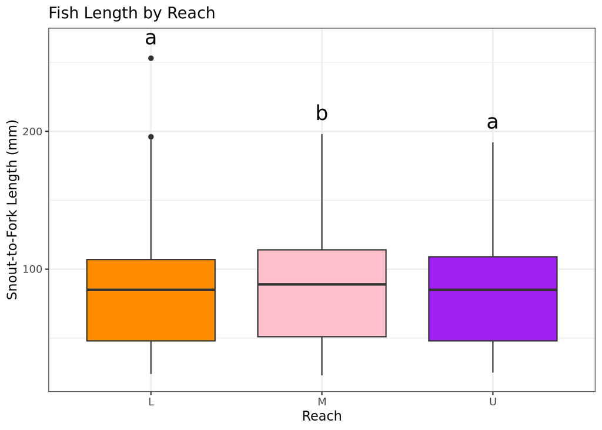

```r
letters_df <- tibble(
  reach = c("L", "M", "U"),
  Letter = c("a", "b", "a")
)

trout_summary <- trout_data %>%
  group_by(reach) %>%
  summarise(mean_length = mean(length_1_mm, na.rm = TRUE),
            sd_length = sd(length_1_mm, na.rm = TRUE),
            max_length = max(length_1_mm, na.rm = TRUE)) %>%
  left_join(letters_df, by = "reach")

# Create a boxplot with significance letters
trout_fig4 <- ggplot(trout_data, aes(x = reach, y = length_1_mm, fill = reach)) +
  geom_boxplot() +
  geom_text(data = trout_summary, aes(x = reach, y = max_length + 10, label = Letter),
            size = 6, vjust = 0) +  # Position letters correctly
  scale_fill_manual(values = c("darkorange", "pink", "purple")) +
  labs(x = "Reach", y = "Snout-to-Fork Length (mm)", fill = "Reach",
       title = "Fish Length by Reach") +
  theme_bw() +
  theme(legend.position = "none")

# Display the final plot
print(trout_fig4)
```

```r
cat("This boxplot shows the distribution of fish length across different reaches (L, M, U). The letters above each box indicate statistical groupings based on Dunn’s post-hoc test. Groups sharing the same letter are not significantly different, whereas groups with different letters indicate a significant difference in fish length (alpha = 0.05).")
```

[output not shown]

#(3) Contingency Tables and the Chi-Squared Test

1. Using the dataset you created above including only cutthroat trout, create a contingency table that includes counts of trout found in diﬀerent channel habitat types (unittype) by reach (reach). If you’re unsure how to create this kind of table, think back to the group_by() and summarize() functions you learned last week. Also, you may want to explore the pivot_wider() and pivot_longer() functions for pivoting data from long to wide format. Create a table using the gt() function with an appropriate caption to display raw fish counts.

```r
trout_summary_unittypebyreach <- trout_data %>%
  group_by(unittype, reach) %>%
  summarize(count = n(), .groups = "drop")

habitatbyreach_table <- trout_summary_unittypebyreach %>%
  select(unittype, reach, count) %>%
  pivot_wider(names_from = reach, values_from = count)

# Make this table a dataframe
habitatbyreach_df <- as.data.frame(habitatbyreach_table)

# Add row totals
habitatbyreach_df <- habitatbyreach_df %>%
  mutate(Total = rowSums(select(., L, M, U), na.rm = TRUE))

habitat_gt <- habitatbyreach_df %>%
  gt() %>%
  tab_header(title = "Fish Habitat Counts by Reach") %>%
  cols_label(
    unittype = "Habitat Type",
    L = "L Reach",
    M = "M Reach",
    U = "U Reach",
    Total = "Total"
  ) %>%
  grand_summary_rows(
    columns = c(L, M, U, Total),
    fns = list(Total = ~sum(., na.rm = TRUE))
  ) %>%
  data_color(
    columns = c(L, M, U),
    palette = c("#C0D8F0", "#5A7ECB"),
    alpha = 0.75
  )

# Display the table
habitat_gt
```

Fish Habitat Counts by Reach

|  | Habitat Type | L Reach | M Reach | U Reach | Total |
| --- | --- | --- | --- | --- | --- |
|  | C | 3951 | 2984 | 4484 | 11419 |
|  | I | 7 | NA | 16 | 23 |
|  | IP | 79 | 6 | 20 | 105 |
|  | P | 1218 | 2121 | 2131 | 5470 |
|  | R | 33 | 94 | 293 | 420 |
|  | S | 2 | NA | 7 | 9 |
|  | SC | 1205 | 1106 | 66 | 2377 |
|  | NA | 220 | 210 | 180 | 610 |
| Total | — | 6715 | 6521 | 7197 | 20433 |

2. Before proceeding further, write out your null and alternative hypotheses for performing a chi-squared test on this dataset. Then, run a chi-squared test on the counts dataset you have created. You may want to use the column_to_rownames() function to make sure the only values in cells of your contingency table are trout counts before running your chi-squared test. Write out your findings as you would in a report, including language about the habitat type where most fish are counted in each reach.

Null Hypothesis: The likelihoods of all possible outcomes for habitat type and reach combinations for Cutthroat trout are the same.

Alternative Hypothesis: TThe likelihoods of all possible outcomes for habitat type and reach combinations for Cutthroat trout are not the same.

```r
habitat_matrix <- habitatbyreach_df %>%
  filter(!is.na(unittype)) %>%  # Remove NA rows in unittype
  column_to_rownames(var = "unittype") %>%  # Convert unittype to row names
  select(L, M, U) %>%  # Keep only numeric columns
  replace(is.na(.), 0)  # Replace NA counts with 0

# Run Chi-Square test
chi_test <- chisq.test(habitat_matrix)
chi_test$observed
```

```
##       L    M    U
## C  3951 2984 4484
## I     7    0   16
## IP   79    6   20
## P  1218 2121 2131
## R    33   94  293
## S     2    0    7
## SC 1205 1106   66
```

```r
chi_test$expected
```

```
##              L           M           U
## C  3741.431923 3635.439086 4042.128992
## I     7.535943    7.322454    8.141603
## IP   34.403218   33.428593   37.168188
## P  1792.243858 1741.470514 1936.285628
## R   137.612874  133.714372  148.672754
## S     2.948847    2.865308    3.185845
## SC  778.823337  756.759673  841.416990
```

```r
chi_test$stdres
```

```
##              L          M          U
## C    6.4172665 -20.098420  13.280366
## I   -0.2382342  -3.279482   3.428538
## IP   9.2973555  -5.761328  -3.512934
## P  -19.4407652  12.945704   6.470005
## R  -10.9927929  -4.204688  14.885411
## S   -0.6740172  -2.050733   2.659271
## SC  19.8522229  16.391059 -35.452296
```

```r
chi_test$parameter #for finding degrees of freedom
```

```
## df
## 12
```

There is a significant association between habitat and reach for Cutthroat trout (X²(12) = 1914.4, p<0.001). The most trout were found in Cascade (C) habitat in the Lower (L) reach, Cascade (C) habitat in the Middle (M) reach, and Cascade (C) habitat in the Upper (U) reach.